# Contrôle Optimale

Dans ce mini-projet on va étudier un système de contrôle. On trouvera ensuite les commandes qui permettent d’aller d’un état à l’autre du système de façon optimale par rapport à un critère donné suivant les méthodes étudiés en cours.

# Système de contrôle

Un système de contrôle est un système dont l’état à l’instant $t$ est décrit par $n$ variables $x_1,\ldots,x_n$. On définit le vecteur d’état du système $x(t)=\left(x_1(t),\ldots,x_n(t)\right)\in\mathbb{R}^n$.

On dispose de $m$ variables de contrôle $u_1,\ldots,u_m$ définissant la commande appliquée à l’instant $t$ par le vecteur $u(t)=\left(u_1(t),\ldots,u_m(t)\right)\in\mathbb{R}^m$.

L’évolution du système est décrit par son **équation d’état**.
$$\boxed{\dot{x}(t) = f(t, x(t), u(t))}$$

Un système contrôle est défini par une équation d’état et une condition initiale.
$$\begin{cases}
\dot{x} = f(t, x(t), u(t)) & \forall t\in [t_0,\infty[\\
x(t_0) &\text{condition initiale donnée}
\end{cases}$$

On dit qu’un état $x^*$ est accessible à partir d’un état initial $x(t_0)$ s’il existe une commande $\bar u(t)$ qui ramène le système à l’état $x^*$ en *temps fini* $T$.
$$\exists T<\infty, \dot x = f(t,x(t),\bar u(t)) \implies x(T)=x^*$$

# L’état du système

On considère un système bilinéaire $S$ donné par son équation d’état.

$$\dot{x}(t)= Ax(t)+ u(t)Bx(t)\quad\mathrm{o\grave{u}}\quad
\begin{cases}
x(t)\in\mathbb{R}^n\\
u(t)\in\mathbb{R}\\
A,B\in\mathbb{R}^{n\times n}
\end{cases}$$

L’équation d’état se reécrit
$$\dot{x}(t)= \left(A+u(t)B\right)x(t)$$

Pour un contrôle constant $u(t)=u,\forall t\in[t_0,T]$ le système devient
$$\dot{x}(t)= \underbrace{\left(A + uB\right)}_{M(u)}\cdot x(t)\quad\mathrm{o\grave{u}}\quad M(u)\in\mathbb{R}^{n\times n}$$

L’équation d’état devient alors une EDO linéaire.

$$\begin{align}
& \dot{x}(t)= Mx(t)\\
& \dot{x}(t)- Mx(t)= 0 \\
& e^{-Mt}\dot{x}(t)- e^{-Mt} Mx(t)= 0 \\
& e^{-Mt}\cdot\frac{x(t)}{\mathrm{d}t} + \frac{\mathrm{d}}{\mathrm{d}t}\left(e^{-Mt}\right)\cdot x(t)= 0 \\
& \frac{\mathrm{d}}{\mathrm{d}t}\left(e^{-Mt}\cdot x(t)\right) = 0\\
& \int_{t_0}^t\frac{\mathrm{d}}{\mathrm{d}s}\left(e^{-Ms}\cdot x(s)\right)\mathrm{d}s= 0\\
& \left. e^{-Ms}\cdot x(s)\right\rvert_{t_0}^t = 0\\
& e^{-Mt}\cdot x(t)- e^{-Mt_0}\cdot x(t_0) = 0\\
& x(t)= e^{M\left(t-t_0\right)}\cdot x(t_0)
\end{align}$$

L’état du système est donc connu à chaque instant $t\in[t_0,T]$.
$$\boxed{x(t)= e^{M\left(t-t_0\right)}\cdot x(t_0)}$$

Prenons un exemple pour $n=3$ la matrice $M$ donnée.

$$M = \left[\begin{matrix}0 & a & b\\- a & 0 & - u\\- b & u & 0\end{matrix}\right]\quad\text{avec}\quad\begin{cases}
a,b\in\mathbb{R}\\
w = \sqrt{a^2+b^2+u^2}
\end{cases}$$

Afin de connaître l’état du système, nous avons besoin de calculer $e^{Mt}$, on utilisera la transformée de laplace inverse.

$$e^{Mt} = \mathcal{L}^{-1}\left(\left(sI-M\right)^{-1}\right)(t)$$

On utilisera la formule suivante pour calculer la matrice inverse de $sI-M$.

$$(sI-M)^{-1} = \frac{1}{\det(sI-M)}
{\mathrm{com}(sI-M)}^{\top}$$

$$sI-M = \left[\begin{matrix}s & - a & - b\\a & s & u\\b & - u & s\end{matrix}\right]$$

Ensuite on calcule le déterminant de la matrice résultante
$$\det(sI-M) = s \left(s^{2} + w^{2}\right) = s(s-iw)(s+iw)$$

On en déduit que $\mathrm{Sp}(M) = \left\{0, iw, -iw\right\}$. Comme la diagonalisation de $M$ est complexe, il vaut mieux calculer son exponentielle par la transformée de laplace inverse.

$$(sI-M)^{-1} = \frac{1}{s \left(s^{2} + w^{2}\right)}{\left[\begin{matrix}s^{2} + u^{2} & - a s + b u & - a u - b s\\a s + b u & b^{2} + s^{2} & - a b + s u\\- a u + b s & - a b - s u & a^{2} + s^{2}\end{matrix}\right]}^{\top}
= \left[\begin{matrix}\frac{s^{2} + u^{2}}{s \left(s^{2} + w^{2}\right)} & \frac{a s + b u}{s \left(s^{2} + w^{2}\right)} & \frac{- a u + b s}{s \left(s^{2} + w^{2}\right)}\\\frac{- a s + b u}{s \left(s^{2} + w^{2}\right)} & \frac{b^{2} + s^{2}}{s \left(s^{2} + w^{2}\right)} & \frac{- a b - s u}{s \left(s^{2} + w^{2}\right)}\\\frac{- a u - b s}{s \left(s^{2} + w^{2}\right)} & \frac{- a b + s u}{s \left(s^{2} + w^{2}\right)} & \frac{a^{2} + s^{2}}{s \left(s^{2} + w^{2}\right)}\end{matrix}\right]$$

En appliquant la transformée de laplace inverse on obtient
$$e^{Mt} = \mathcal{L}^{-1}\left(\left(sI-M\right)^{-1}\right)(t) = \left[\begin{matrix}\frac{- u^{2} \cos{\left(t w \right)} + u^{2} + w^{2} \cos{\left(t w \right)}}{w^{2}} & \frac{a w \sin{\left(t w \right)} - b u \cos{\left(t w \right)} + b u}{w^{2}} & \frac{a u \cos{\left(t w \right)} - a u + b w \sin{\left(t w \right)}}{w^{2}}\\\frac{- a w \sin{\left(t w \right)} - b u \cos{\left(t w \right)} + b u}{w^{2}} & \frac{- b^{2} \cos{\left(t w \right)} + b^{2} + w^{2} \cos{\left(t w \right)}}{w^{2}} & \frac{a b \cos{\left(t w \right)} - a b - u w \sin{\left(t w \right)}}{w^{2}}\\\frac{a u \cos{\left(t w \right)} - a u - b w \sin{\left(t w \right)}}{w^{2}} & \frac{a b \cos{\left(t w \right)} - a b + u w \sin{\left(t w \right)}}{w^{2}} & \frac{- a^{2} \cos{\left(t w \right)} + a^{2} + w^{2} \cos{\left(t w \right)}}{w^{2}}\end{matrix}\right]$$

L’état du système à l’instant $t$ est donc donné par l’expression de son vecteur d’état.

$$x(t)= \left[\begin{matrix}\frac{- u^{2} \cos{\left(w \left(t - t_{0}\right) \right)} + u^{2} + w^{2} \cos{\left(w \left(t - t_{0}\right) \right)}}{w^{2}} & \frac{a w \sin{\left(w \left(t - t_{0}\right) \right)} - b u \cos{\left(w \left(t - t_{0}\right) \right)} + b u}{w^{2}} & \frac{a u \cos{\left(w \left(t - t_{0}\right) \right)} - a u + b w \sin{\left(w \left(t - t_{0}\right) \right)}}{w^{2}}\\\frac{- a w \sin{\left(w \left(t - t_{0}\right) \right)} - b u \cos{\left(w \left(t - t_{0}\right) \right)} + b u}{w^{2}} & \frac{- b^{2} \cos{\left(w \left(t - t_{0}\right) \right)} + b^{2} + w^{2} \cos{\left(w \left(t - t_{0}\right) \right)}}{w^{2}} & \frac{a b \cos{\left(w \left(t - t_{0}\right) \right)} - a b - u w \sin{\left(w \left(t - t_{0}\right) \right)}}{w^{2}}\\\frac{a u \cos{\left(w \left(t - t_{0}\right) \right)} - a u - b w \sin{\left(w \left(t - t_{0}\right) \right)}}{w^{2}} & \frac{a b \cos{\left(w \left(t - t_{0}\right) \right)} - a b + u w \sin{\left(w \left(t - t_{0}\right) \right)}}{w^{2}} & \frac{- a^{2} \cos{\left(w \left(t - t_{0}\right) \right)} + a^{2} + w^{2} \cos{\left(w \left(t - t_{0}\right) \right)}}{w^{2}}\end{matrix}\right] \cdot\begin{bmatrix}x_1(t_0)\\x_2(t_0)\\x_3(t_0)\end{bmatrix}$$

# Contrôle Optimal

## Notions d’optimalité

Un problème de contrôle optimale consiste à trouver une commande $u^*$ qui ramène le système à un état $x^*$ en minimisant un critère donnée par une fonction qu’on appelle **fonction coût**.

La fonction coût représente le coût du système à un état donné suivant une commande donnée.
$$g:\mathbb{R}\times\mathbb{R}^n\times\mathbb{R}^m \rightarrow \mathbb{R}$$

Le coût total d’une commande $u:[t_0,T]\rightarrow\mathbb{R}^m$ se donne par
$$C(u) = \int_{t_0}^T g(t, x(t), u(t)) \mathrm{d}t$$

Afin de trouver la commande optimale, on définit le système généralisé suivant: On pose
$$x_0(t)=\int_{t_0}^t g(s, x, u) \mathrm{d}s$$
on remarque que $x_0(t_0)=0$ et $x_0(T)=C(u)$. De plus, $\dot{x}_0(t) = g(t, x(t), u(t))$. On définit l’état généralisé du système

$$\tilde{x}(t)=\begin{pmatrix}x_0(t)\\x(t)\end{pmatrix}\begin{matrix}\in\mathbb{R}~\\\in\mathbb{R}^n\end{matrix}
\implies \tilde{x}(t)\in\mathbb{R}^{n+1}$$

On en déduit l’équation d’état généralisé
$$\dot{\tilde{x}}(t) = \begin{pmatrix}\dot{x}_0(t)\\\dot{x}(t)\end{pmatrix}=
\begin{pmatrix}g(t, x(t), u(t))\\f(t, x(t), u(t))\end{pmatrix}=
\tilde{f}(t, x(t), u(t))\in\mathbb{R}^{n+1}$$

Le problème revient à trouver une commande $u^*$ admissible ($\in\mathcal{U}$) qui ramène le système généralisé à l’état
$$\tilde{x}^*=\begin{pmatrix}\min\limits_{u\in\mathcal{U}} C(u)\\ x^*\end{pmatrix}$$

## Temps optimalité

Afin de trouver une commande optimale en temps minimale, il suffit de définir une fonction coût $g(t, x(t), u(t))=g(t)$ croissante par rapport au temps.

En pratique, il suffit de prendre $g(t)=1$ car le coût d’une commande sera donc $C(u)=T-t_0$.

## Le Hamiltonien du système

On définit le Hamiltonien du système $S=(x, u, f)$ par la fonction.

$$\begin{align}
H: \mathbb{R}^n\times\left(\mathbb{R}^n\setminus\left\{0_{\mathbb{R}^n}\right\}\right)\times\mathbb{R}^m &\rightarrow \mathbb{R}\\
(x, p, u) &\mapsto \left\langle p(t){,}f(t,x(t),u(t))\right\rangle
= \left\langle p(t){,}\dot{x}(t)(t)\right\rangle
\end{align}$$

où $p$ est le vecteur adjoint au système.

Pour chercher la commande optimale, on considère le Hamiltonien du système généralisé $\tilde{S}=(\tilde{x},u, \tilde{f})$.

$$\tilde{H}(\tilde{x}, \tilde{p}, u) = \left\langle\tilde{p}{,}\tilde{f}(t,x,u)\right\rangle
= p_0\cdot g(t,x,u) + \left\langle p{,}f(t, x, u)\right\rangle
= \tilde{H}(x, p_0, p, u)$$

Par abus de notation, on écriré le Hamiltonien généralisé sans le tilde car on ne s’intéresse pas au Hamiltonien du système $S$.

On reconsidère l’équation d’état du système : $\dot x = Ax + uBx$

Il s’agit d’un système affine de la forme $\dot x = F(x) + u\cdot G(x)$ que l’on peut identifier les fonctions $F$ et $G$, d’où

$$\begin{cases}
F(x) = Ax &\Rightarrow \nabla F(x) = A\\
G(x) = Bx &\Rightarrow \nabla G(x) = B
\end{cases}$$

Cette écriture nous permettra de mieux exprimer la fonction hamiltonienne. Le Hamiltonien se donne alors par:

$$H(x, p, u) = p_0 + \left\langle p{,}\dot{x}(t)\right\rangle
= p_0 + \left\langle p{,}Mx(t)\right\rangle
= p_0 + \left\langle p{,}Ax + uBx\right\rangle$$

Revenons à notre problème, on cherche à emmener le système de l’état $x(t_0=0)$ à l’état $x(T)$ en temps minimal étant donné
$$x(0) = \left[\begin{matrix}0\\0\\1\end{matrix}\right] \quad\text{et}\quad
x(T) = \begin{bmatrix}0\\\frac{1}{\sqrt 2}\\\frac{1}{\sqrt 2}\end{bmatrix}$$

On applique le Principe du Maximum de Pontryagin (PMP), on pose les équations du PMP:

**L’équation d’état** se donne par $\dot{x}(t)= \frac{\partial H}{\partial p}$. En effet, $H(x,p,u) = p_0 + \left\langle p{,}Mx\right\rangle$ d’où $\frac{\partial H}{\partial p} = Mx = \dot{x}(t)$.

**L’équation adjointe** se donne par $\dot{p}(t) = -\frac{\partial H}{\partial x}$.
$$\begin{align}
H(x, p, u) &= p_0 + \left\langle p{,}Mx\right\rangle\\
&= p_0 + \left\langle Mx{,}p\right\rangle\\
&= p_0 + {\left(Mx\right)}^{\top}p\\
&= p_0 + {x}^{\top}{M}^{\top}p\\
&= p_0 + \left\langle x{,}{M}^{\top}p\right\rangle\\
\Rightarrow\frac{\partial H}{\partial x} &= {M}^{\top}p
\end{align}$$

Dans notre problème $M$ est anti-symétrique (i.e. ${M}^{\top} = -M$), d’où $\frac{\partial H}{\partial x} = -Mp$.

L’équation adjointe est donc $\dot{p}(t) = M p(t)$, on remarque que l’équation adjointe est l’équation d’état du système dans le cas d’un système *bilinéaire affine anti-symétrique*.

On en déduit que $p(t) = e^{Mt}p(0)$.

Il faut que $p_0 \leq 0$ également.

**La condition de maximisation :** On cherche une commande $u^*$ qui maximise le Hamiltonien $\forall u\in\mathcal{U}$.

$$\begin{align}
u^* &= \mathop{\mathrm{argmax}}_{u\in\mathcal{U}}~H(x, p, u)\\
&= \mathop{\mathrm{argmax}}_{u\in\mathcal{U}}~\left(p_0 + \left\langle p{,}Ax + uBx\right\rangle\right)\\
&= \mathop{\mathrm{argmax}}_{u\in\mathcal{U}}~\left(p_0 + \left\langle p{,}Ax\right\rangle + u\left\langle p{,}Bx\right\rangle\right)\\
&= \mathop{\mathrm{argmax}}_{u\in\mathcal{U}}~\left(u\left\langle p{,}Bx\right\rangle\right)\\
&= \mathop{\mathrm{argmax}}_{u\in\mathcal{U}}~u\cdot\underbrace{\left\langle p{,}Bx\right\rangle}_{\phi(t)}\\
&= \mathop{\mathrm{argmax}}_{u\in\mathcal{U}}~u\cdot\phi(t)
\end{align}$$

Comme le Hamiltonien est une fonction affine par rapport à $u$, le maximum ne peut être atteint que pour $u$ bornée. On prend $\left\lvert u(t)\right\rvert\leq 1$, d’où
$$u^*(t) = \mathrm{sgn}(\phi(t)) = \mathrm{sgn}(\left\langle p{,}Bx\right\rangle)$$

On appelle $\phi(t)=\left\langle p{,}Bx\right\rangle$ la **fonction de commutation**.

Il s’agit donc d’une commande *bang-bang*, on cherche alors les trajets optimales.

$$x_{u=1}(t) = \left[\begin{matrix}\frac{a \cos{\left(t w \right)} - a + b w \sin{\left(t w \right)}}{w^{2}}\\\frac{a b \cos{\left(t w \right)} - a b - w \sin{\left(t w \right)}}{w^{2}}\\\frac{- a^{2} \cos{\left(t w \right)} + a^{2} + w^{2} \cos{\left(t w \right)}}{w^{2}}\end{matrix}\right] \quad\text{,}\quad x_{u=-1}(t) = \left[\begin{matrix}\frac{- a \cos{\left(t w \right)} + a + b w \sin{\left(t w \right)}}{w^{2}}\\\frac{a b \cos{\left(t w \right)} - a b + w \sin{\left(t w \right)}}{w^{2}}\\\frac{- a^{2} \cos{\left(t w \right)} + a^{2} + w^{2} \cos{\left(t w \right)}}{w^{2}}\end{matrix}\right]$$

On rappelle qu’on avait trouvé que $\mathrm{Sp}(M) = \left\{0, iw, -iw\right\}$, on peut ainsi en déduire que :

- L’état pour une commande fixée $x_u(t)$ vit dans un hyperplan de $\mathbb{R}^3$ que l’on note $E_u$ tel que $\mathrm{dim}(E_u)=2$ car $M$ a une valeur propre nulle.
- Les trajectoires de $x_u(t)$ (pour une commande fixée) sont elliptiques dans $E_u$ car les deux valeurs propres non-nulles de $M$ sont conjugées et purement imaginaires.
- Pour $a,b$ fixés, l’état du système vit dans la surface d’un ellipsoïde, si les trajectoires $x_{u=1}$ et $x_{u=-1}$ sont indépendants alors tous les points sur la surface de l’ellipsoïde sont accessible à partir de $x(t_0)$.

On trace le champs de vecteur du système à partir de $x(0)=(0, 0, 1)$ pour $a=1,b=0$ sur et les trajectoires bang-bang à l’aide de *python*.

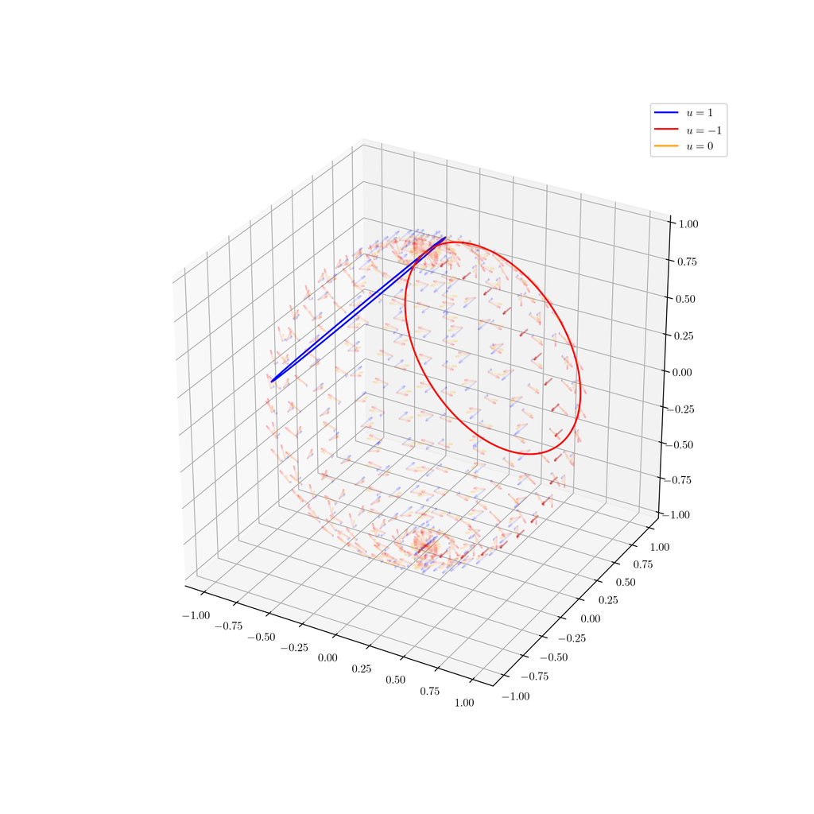

Nous cherchons alors la commande optimale $u^*(t)$ à chaque instant $t$.

- Si $\phi(t)\geq 0$ alors $u^*(t) = 1$.
- Si $\phi(t)\leq 0$ alors $u^*(t) = -1$.
- Si $\phi(t) = 0$ alors $u^*(t) = u^*$ trajectoire singulière.

Nous identifiant les matrices $A$ et $B$ de notre système.

$$M(u) = \left[\begin{matrix}0 & a & b\\- a & 0 & - u\\- b & u & 0\end{matrix}\right]
= \underbrace{\left[\begin{matrix}0 & a & b\\- a & 0 & 0\\- b & 0 & 0\end{matrix}\right]}_{A} +u \underbrace{\left[\begin{matrix}0 & 0 & 0\\0 & 0 & -1\\0 & 1 & 0\end{matrix}\right]}_{B}$$

D’où $\phi(t) = \left\langle p(t){,}Bx(t)\right\rangle = -p_2(t)x_3(t) +p_3(t)x_2(t)$. De plus, $x(0)={(0,0,1)}^{\top}$ donc $\phi(0) = -p_2(0)$.

Le temps de commutation de la trajectoire optimale est le temps de changement de signe de $\phi$, on cherche alors $t\geq t_0$ tel que $\phi(t) = 0$.

A l’aide du PMP, nous avons pu determiner que notre commande est une commande *bang-bang*, nous pouvons trouver ainsi la commande optimale en cherchant *iterativement* le temps et lieu de commutation permettants d’aller à $x(T)$.

En effet, en prenant $u^*(0)=1$, notre commande est de la forme
$$x(t)=\begin{cases}
e^{M(1)t}\cdot x(0) &\text{si}~t\in[0,t_c[\\
e^{M(-1)t}\cdot x(t_c) &\text{si}~t\in[t_c,T]
\end{cases}$$
où $t_c$ est le temps de commutation et $x(t_c)$ est le lieu de commutation.

En discrétisant le temps $t_n=n\Delta t$ pour $\Delta t$ suffisament petit, nous pouvons chercher iterativement pour chaque $t_n$ si le trajectoire $e^{M(-1)t_n}\cdot x(t_n)$ mène à $x(T)$ en vérifiant s’il existe un point $x_n$ du second trajectoire tel que $\left\lVert x_n-x(T)\right\rVert<\varepsilon$ pour $\varepsilon$ suffisament petit.

```python
from control import plot_vector_field, plot_trajectory, find_optimal

u = [1, -1]
a = 1
b = 0

Xt1, Xt2, Topt = find_optimal(exp_Mt, X0, X1, a_val=a, b_val=b, u_first=u[0], N=1000, epsilon=0.01)
```

```
Optimal trajectory found!
Commutation time: 0.5470216230164956
Commutation position: [-0.14230192 -0.49406899  0.85769808]
Optimal time: 1.6499595295863405
```

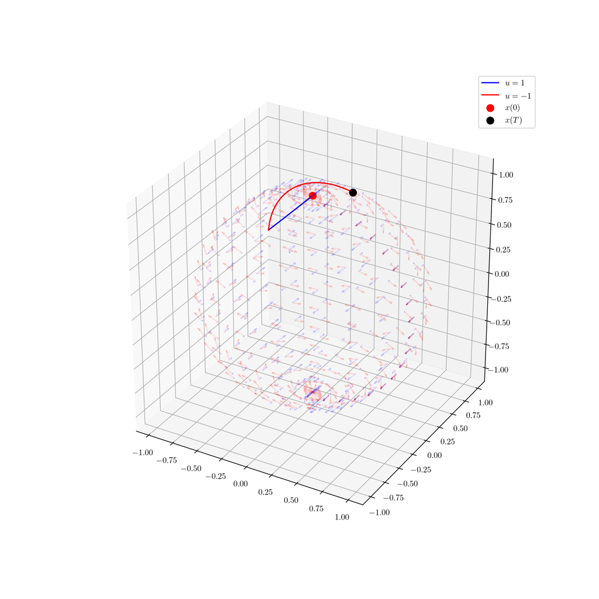

```python
fig = plt.figure(figsize=(10, 10))
ax = fig.gca(projection='3d')
plot_vector_field(M, R=float(X0.norm()), a_val=a, b_val=b, u_val=u, ax=ax, alpha=0.1, plot_sphere=False)
plot_trajectory(Xt1, Xt2, u=u, x0=X0, x1=X1, ax=ax)
plt.show()
```

Vérifions si le trajectoire bang-bang qui commence par $u(0)=-1$ est la trajectoire optimale.

```python
u = [-1, 1]

Xt1, Xt2, Topt = find_optimal(exp_Mt, X0, X1, a_val=a, b_val=b, u_first=u[0], N=1000, epsilon=0.01)
```

```
Optimal trajectory found!
Commutation time: 0.5470216230164956
Commutation position: [0.14230192 0.49406899 0.85769808]
Optimal time: 4.740854066142961
```

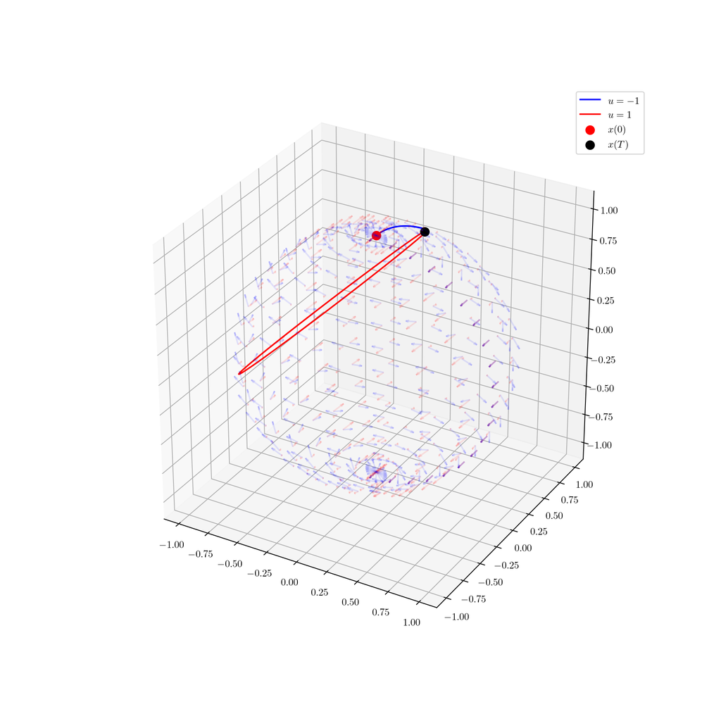

```python
fig = plt.figure(figsize=(10, 10))
ax = fig.gca(projection='3d')
plot_vector_field(M, R=float(X0.norm()), a_val=a, b_val=b, u_val=u, ax=ax, alpha=0.1, plot_sphere=False)
plot_trajectory(Xt1, Xt2, u=u, x0=X0, x1=X1, ax=ax)
plt.show()
```

## Equation de Hamilton-Jacobi-Bellman

On définit la fonction de Bellman par

$$V(t,x(t)) = \min_{u\in[t,T[} \int_t^T g(s, x(s), u(s))\mathrm{d}s$$
avec $V(T, x(T)) = 0$.

Dans le cas d’un problème de temps-optimalité nous avons $g(t, x(t), u(t)) = 1$ d’où

$$V(t, x(t)) = \min_{u\in[t,T[} (T-t) = T-t$$

L’équation de Hamilton-Jacobi-Bellman (HJB) se donne par

$$\frac{\partial V}{\partial t} + \min_{u\in\mathcal{U}}\left(\frac{\partial V}{\partial x}\cdot f(t,x(t),u(t)) + g(t,x(t),u(t))\right) = 0$$

Dans notre système,
$$\begin{cases}
\frac{\partial V}{\partial t} = -1\\
\frac{\partial V}{\partial x} = 0
\end{cases}\implies (-1) + \min_{u\in\mathcal{U}}\left(0 + 1\right) = 0$$

L’équation de HJB est donc vérifiée pour tout $u\in\mathcal{U}$.

# Conclusion

Le système étudié represente deux cas spéciaux de système de contrôle.

- **Système affine en $u$:** $f(t, x, u) = F(x) + uG(x)$
- **Système linéaire en $x$:** $f(t, x, u) = Mx$

De plus, nous avions une matrice $M$ antisymétrique, ce qui a présenté un cas intéressant d’un vecteur adjoint vérifiant lui-même l’équation d’état.

Néanmoins, la recherche de la commande qui mène le système en temps minimal de $x(0)$ à $x(T)$ représente un cas important de problème de contrôle optimal.

Ces propriétés ont donné des cas spéciales de la forme du Hamiltonien et ses dérivés, et de l’équation de HJB.

En conclusion, ce projet a été une opportunité d’étudier au plus près un système de contrôle optimal en trois dimensions, et de mieux visualiser l’état du système et son comportement, et a ainsi permis de mieux comprendre le domaine de contrôle optimal.